# Å plotte funksjoner av flere variabler

**Læringsmål:**

- Plotting med for-løkker
- Funksjoner av flere variabler

**Oversikt:**

- Oppgave a) plotte funksjon med 2 variabler
- Oppgave b) plotte funksjon med 3 variabler

Ofte er det veldig praktisk å kunne plotte flere funksjoner i en graf for å lettere kunne sammenligne dem. For dette er en *for*-løkke veldig praktisk. Fra tidligere vet vi at matplotlib og numpy kan brukes til å plotte kurver slik som vist nedenfor.

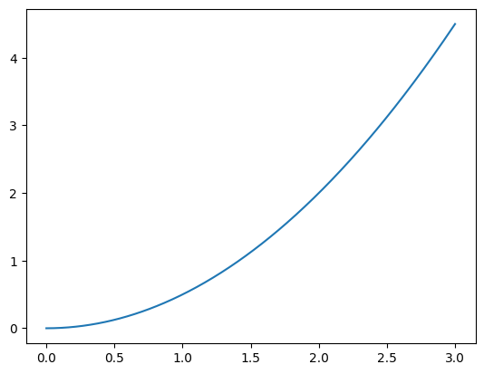

```python
import numpy as np
import matplotlib.pyplot as plt


def f(x):
    return x * x / 2


x = np.linspace(0, 3, 501)
y = f(x)

plt.plot(x, y)
```

Når flere kurver skal plottes i samme graf kan dette gjøres ved å kalle funksjon `plt.plot()` flere ganger som i koden nedenfor. Når vi gjør dette er det vanlig å inkludere en merkelapp, eller *label*, som lar oss se forskjellen mellom de to kurvene.

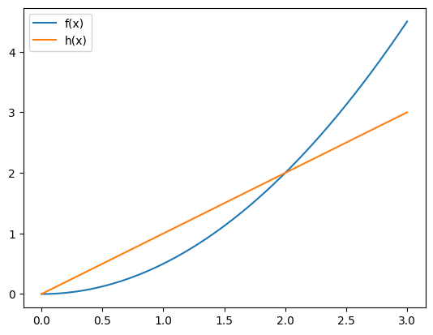

```python
import numpy as np
import matplotlib.pyplot as plt


def f(x):
    return x * x / 2


def h(x):
    return x


x = np.linspace(0, 3, 501)
yf = f(x)
yh = h(x)

plt.plot(x, yf, label="f(x)")
plt.plot(x, yh, label="h(x)")

plt.legend()
```

Denne muligheten for å vise flere kurver i samme figur kan også anvendes til å gi en grafisk fremstilling av funksjoner med *mer enn én* variabel.

## Eksempel på funksjon av flere variabler: *normalfordelingskurven*

Selv om du ikke enda har hatt emnet statistikk, er sjansene store for at du har sett en [normalfordelingskurve](https://no.wikipedia.org/wiki/Normalfordeling) før:

[figure not shown]

Det er ikke nødvendig å forstå normalfordelingen for å løse opppgaven, men kort fortalt så ser vi her sjansen en tilfeldig variabel med normal sannsynlighetsfordeling har for å havne innenfor et gitt område av grafen. Som grafen illustrerer, er det en parameter $\sigma$ som forteller oss at variabelen har en gitt sannsynlighet for å havne innenfor området $0 \pm \sigma$. Normalfordeling er en sannsynlighetsfordeling som er veldig nyttig til å modellere bl.a. måleusikkerhet ved målinger i den virkelige verden.

Funksjonen som beskriver den generelle normalfordelingskurven er oppgitt som følger:

### $$f(x, \mu, \sigma) = \frac{1}{\sigma \cdot \sqrt{2\pi}} \cdot e^{-\frac{(x - \mu)^2}{2\sigma^2}}$$

## a)

Din oppgave er å bruke et plott for å vise normalfordelingskurven $f(x, \mu, \sigma)$ i området $-5 \leq x \leq 5$ gitt parametrene i tabellen nedenfor. Plottet skal ha merkelapper som viser verdien av $\sigma$ for de ulike kurvene. Det *skal* benyttes en for-løkke for å plotte de ulike figurene.

| Kurve nr. | $$\mu$$ | $$\sigma$$ |
| --- | --- | --- |
| 1 | 0 | 1 |
| 2 | 0 | 2 |
| 3 | 0 | 3 |
| 4 | 0 | 4 |

*PS: Her er et forslag til hvordan figuren kan se ut ved riktig utførelse.*  
*Nyttig å vite: for å skrive mattesymboler i matplotlib-figurer kan vi bruke [latex math](https://www.overleaf.com/learn/latex/Mathematical_expressions). Esempel:* `label=f"$\\sigma = {sigma}$"` *kan brukes på merkelappene i dette plottet. Dette er dog ikke nødvendig for å få oppgaven godkjent.*

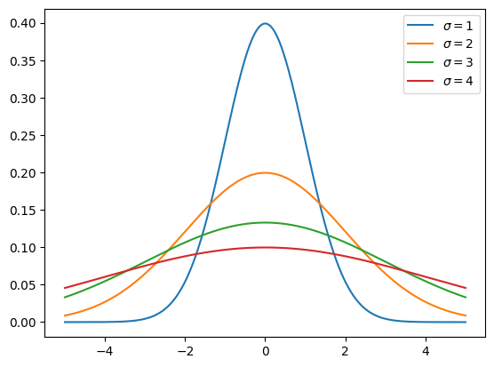

```python
def normalfordeling(x, mu, sigma):
    return 1 / (sigma * np.sqrt(2 * np.pi)) * np.exp(-((x - mu) ** 2) / (2 * sigma ** 2))


x = np.linspace(-5, 5, 501)

import matplotlib.pyplot as plt

for mu, sigma in [(0, 1), (0, 2), (0, 3), (0, 4)]:
    y = normalfordeling(x, mu, sigma)
    plt.plot(x, y, label=f"$\\sigma = {sigma}$")
    plt.legend()
```

```python
# Denne cellen brukes under retting. La Stå!
```

All tests passed.

```
5.0
```

## b)

I deloppgave **a)** endret vi kun på parameteren $\sigma$ i løpet av plottingen, men ikke på parameteren $\mu$ som er kjent som *forventingsverdien* (med andre ord, gjennomsnittet til den tilfeldige variabelen over tid). Vi skal nå lage en figur der vi viser normalfordelingskurven for forskjellige verdier av $\mu$ og $\sigma$:

| Kurve nr. | $$\mu$$ | $$\sigma$$ |
| --- | --- | --- |
| 1 | 0 | 1 |
| 2 | 1 | 0.6 |
| 3 | -2 | 0.8 |
| 4 | 0 | 2 |

*PS: Her er et forslag til hvordan figuren kan se ut ved riktig utførelse.*

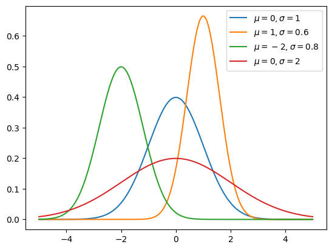

```python
x = np.linspace(-5, 5, 501)

import matplotlib.pyplot as plt

for mu, sigma in [(0, 1), (1, 0.6), (-2, 0.8), (0, 2)]:
    y = normalfordeling(x, mu, sigma)
    plt.plot(x, y, label=f"$\\mu = {mu}, \\sigma = {sigma}$")
    plt.legend()
```

**Nyttig tips:** For å iterere gjennom *to* lister i parallell kan man bruke funksjonen [`zip`](https://docs.python.org/3/library/functions.html#zip). Eksempelet nedenfor viser hvordan det kan brukes for å skrive ut verdiene i to like lange lister med $x$- og $y$ verdier.

```python
for x, y in zip([1, 2, 3], [1, 4, 9]):
    print(f"{x = }, {y = }")
```

```
x = 1, y = 1
x = 2, y = 4
x = 3, y = 9
```

```python
# Denne cellen brukes under retting. La Stå!
```

All tests passed.

```
5.0
```